# Module 20

#### Visualizing Data - Organizing Terms by Frequency

We can get the frequencies with which different terms appear across the set of documents as a vector by converting the document term matrix into a matrix and then summing the column counts.

```r
dirCorpusFreq <- colSums(as.matrix(dirCorpusDTM))
dirCorpusFreq <- sort(dirCorpusFreq, decreasing = TRUE)
dirCorpusDF <- data.frame(word = names(dirCorpusFreq), freq = dirCorpusFreq)
rownames(dirCorpusDF) <- NULL
head(dirCorpusDF)
```

```
##     word freq
## 1  speci 3224
## 2   male 2975
## 3    one 2920
## 4 differ 2467
## 5  femal 2225
## 6   mani 1743
```

```r
fileCorpusFreq <- colSums(as.matrix(fileCorpusDTM))
fileCorpusFreq <- sort(fileCorpusFreq, decreasing = TRUE)
fileCorpusDF <- data.frame(word = names(fileCorpusFreq), freq = fileCorpusFreq)
rownames(fileCorpusDF) <- NULL
head(fileCorpusDF)
```

```
##   word freq
## 1  mrs 2497
## 2 will 2460
## 3 must 2239
## 4 said 2156
## 5 much 2026
## 6  one 2019
```

```r
tweetCorpusFreq <- colSums(as.matrix(tweetCorpusDTM))
tweetCorpusFreq <- sort(tweetCorpusFreq, decreasing = TRUE)
tweetCorpusDF <- data.frame(word = names(tweetCorpusFreq), freq = tweetCorpusFreq)
rownames(tweetCorpusDF) <- NULL
head(tweetCorpusDF)
```

```
##       word freq
## 1 american   46
## 2      can   33
## 3     year   32
## 4    today   29
## 5  america   22
## 6    thank   22
```

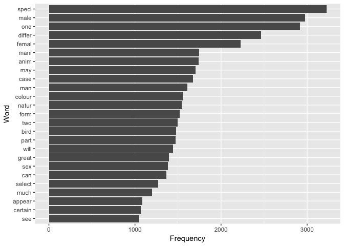

```r
# plotting the most common words: Darwin's books
library(ggplot2)
p <- ggplot(data = dirCorpusDF[1:25, ], aes(x = reorder(word, freq), y = freq)) +
    xlab("Word") + ylab("Frequency") + geom_bar(stat = "identity") + coord_flip()
p
```

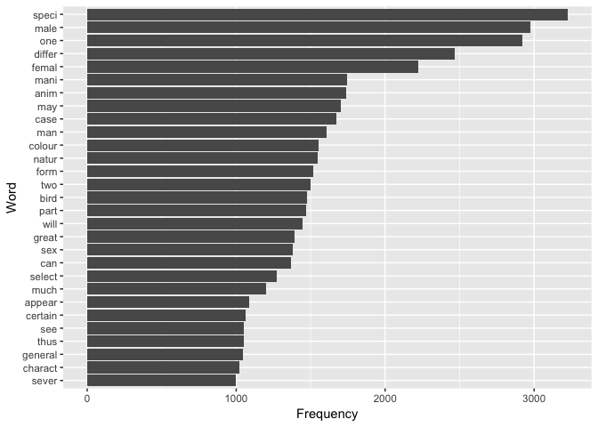

```r
# plotting words that occur at least a certain number of times (here, >=
# 1000)
p <- ggplot(subset(dirCorpusDF, freq >= 1000), aes(x = reorder(word, freq),
    y = freq)) + xlab("Word") + ylab("Frequency") + geom_bar(stat = "identity") +
    coord_flip()
p
```

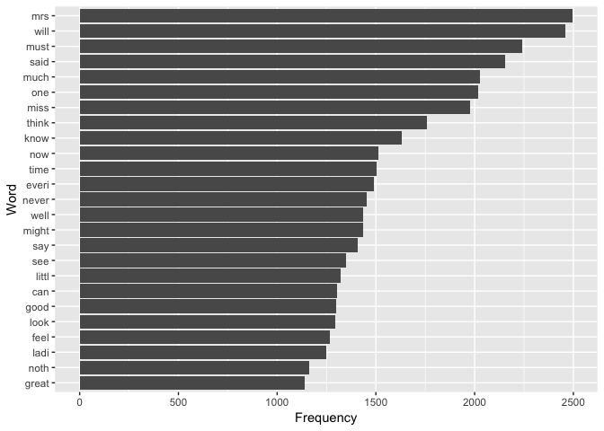

```r
# plotting the most common words: Austen's novels
p <- ggplot(data = fileCorpusDF[1:25, ], aes(x = reorder(word, freq), y = freq)) +
    xlab("Word") + ylab("Frequency") + geom_bar(stat = "identity") + coord_flip()
p
```

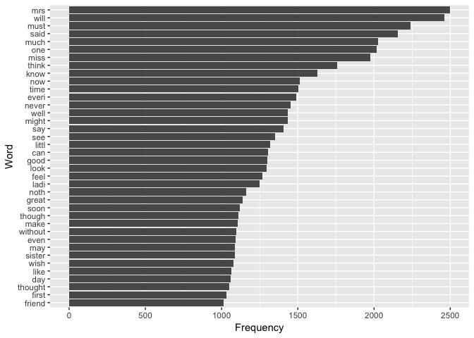

```r
# plotting words that occur at least a certain number of times (here, >=
# 1000)
p <- ggplot(subset(fileCorpusDF, freq >= 1000), aes(x = reorder(word, freq),
    y = freq)) + xlab("Word") + ylab("Frequency") + geom_bar(stat = "identity") +
    coord_flip()
p
```

```r
# an alternative way to find a list of common words and print as a vector
findFreqTerms(fileCorpusDTM, lowfreq = 1000)
```

```
##  [1] "can"     "day"     "even"    "everi"   "feel"    "first"   "friend"
##  [8] "good"    "great"   "know"    "ladi"    "like"    "littl"   "look"
## [15] "make"    "may"     "might"   "miss"    "mrs"     "much"    "must"
## [22] "never"   "noth"    "now"     "one"     "said"    "say"     "see"
## [29] "sister"  "soon"    "think"   "though"  "thought" "time"    "well"
## [36] "will"    "wish"    "without"
```

```r
# we can also find the correlations between words, a measure of how often
# they co-occur across documents
findAssocs(fileCorpusDTM, terms = c("pride", "anger"), corlimit = 0.9)
```

```
## $pride
##        boast   diningroom    gentlemen        proud        guard
##         0.97         0.97         0.96         0.96         0.95
##       reject       unless        chose         lake         sole
##         0.95         0.95         0.94         0.94         0.94
##       abomin         fath         meat        river        anyon
##         0.93         0.93         0.93         0.93         0.92
##      beneath characterist         defi      disdain       master
##         0.92         0.92         0.92         0.92         0.92
##        patro     personag        plead         pool        prone
##         0.92         0.92         0.92         0.92         0.92
##        quest    reprehens       repres     trespass       unfelt
##         0.92         0.92         0.92         0.92         0.92
##        vouch       applic      contain         imit      suitabl
##         0.92         0.91         0.91         0.91         0.91
##     apologis     attorney     incredul       invalu   likelihood
##         0.90         0.90         0.90         0.90         0.90
##      married        offic     regiment       resign     saturday
##         0.90         0.90         0.90         0.90         0.90
##     speaking        studi       visibl
##         0.90         0.90         0.90
##
## $anger
##      absenc    approach        aris        acut        ball       dwelt
##        0.99        0.98        0.98        0.97        0.97        0.97
##      bitter     consist       scarc    teteatet      church      denial
##        0.96        0.96        0.96        0.96        0.95        0.95
##   difficult         vex    grievous        lawn      solemn        went
##        0.95        0.95        0.94        0.94        0.94        0.94
##       appli       began       dwell       felic       occas      reliev
##        0.93        0.93        0.93        0.93        0.93        0.93
##     scarlet       shame      taught     thither    unfavour       vexat
##        0.93        0.93        0.93        0.93        0.93        0.93
##      accord     address      attack     chiefli       cloth     discuss
##        0.92        0.92        0.92        0.92        0.92        0.92
##       impos      inquir        niec       score    steadili      stupid
##        0.92        0.92        0.92        0.92        0.92        0.92
##     success     triumph     unsettl   voluntari       whist      breast
##        0.92        0.92        0.92        0.92        0.92        0.91
##   character       choic      credit  displeasur       girls  handsomest
##        0.91        0.91        0.91        0.91        0.91        0.91
##      import       light      second selfconsequ       slave       trust
##        0.91        0.91        0.91        0.91        0.91        0.91
##       weigh     express      famili      imposs      object      odious
##        0.91        0.90        0.90        0.90        0.90        0.90
##      parish      purpos     upstair
##        0.90        0.90        0.90
```

#### Visualizing Data - Plotting Correlations and Clustering Among Terms and Among Documents

Let's plot the correlations among terms in Barak Obama's tweets. We limit ourselves to terms that appear in at least 11 tweets and where we only show terms with a correlation of at least 0.10 across tweets.

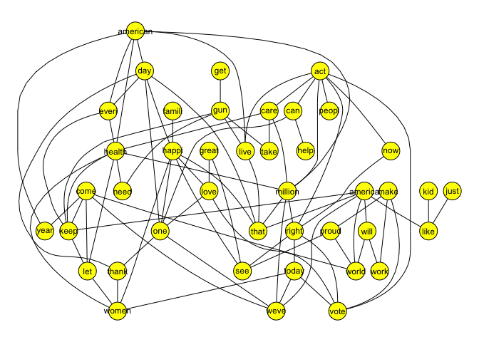

```r
library(Rgraphviz)
attrs = list(node = list(fillcolor = "yellow", fontsize = "30"), edge = list(),
    graph = list())
plot(tweetCorpusDTM, terms = findFreqTerms(tweetCorpusDTM, lowfreq = 11), attrs = attrs,
    corThreshold = 0.1)
```

```r
dev.off()  # clears the plot window for next plot
```

To visualize hierarchal clustering of **documents** in terms of similar term use, we first calculate distances between them and cluster them according to similarity. Let's do this with Jane Austen's novels. We use the {dendextend} package to print our dendrogram.

```r
library(cluster)
fileDocDist <- dist(scale(fileCorpusDTM), method = "euclidian")
fitDoc <- hclust(fileDocDist, method = "ward.D2")
library(dendextend)
```

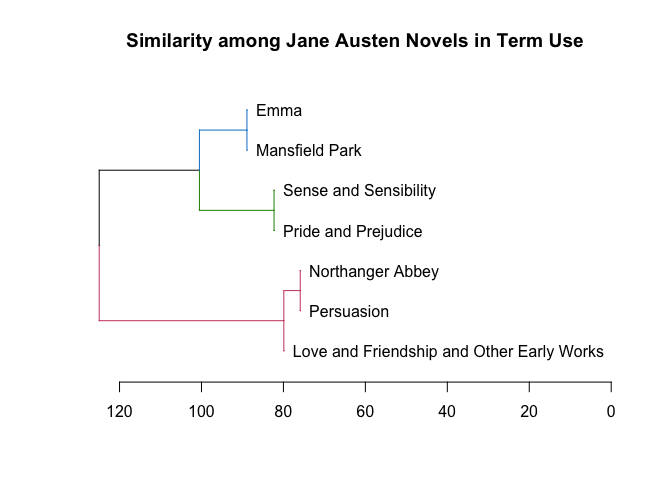

```r
dend <- as.dendrogram(fitDoc)  # similarity among DOCUMENTS
dend <- rotate(dend, 1:length(fitDoc$labels))
dend <- color_branches(dend, k = 3)
dend <- set(dend, "labels_cex", 1)
dend <- hang.dendrogram(dend, hang_height = 0.1)
plot(dend, horiz = TRUE, main = "Similarity among Jane Austen Novels in Term Use")
```

```r
dev.off()  # clears the plot window for next plot
```

To visualize hierarchal clustering of terms in terms of their use across documents, we similarly calculate distances between them and cluster them according to similarity. Below, we regenerate the TDM for President Obama's tweets limiting ourselves to terms that appear in at least 11 tweets.

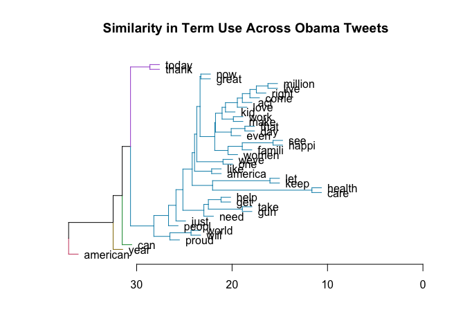

```r
tweetCorpusTDM <- TermDocumentMatrix(tweetCorpus, control = list(bounds = list(global = c(11,
    Inf))))
tweetTermDist <- dist(scale(tweetCorpusTDM), method = "euclidian")
fitTerm <- hclust(tweetTermDist, method = "ward.D2")
dend <- as.dendrogram(fitTerm)  # similarity among TERMS
dend <- rotate(dend, 1:length(fitTerm$labels))
dend <- color_branches(dend, k = 5)
dend <- set(dend, "labels_cex", 1)
dend <- hang.dendrogram(dend, hang_height = 1)
plot(dend, horiz = TRUE, main = "Similarity in Term Use Across Obama Tweets")
```

```r
dev.off()  # clears the plot window for next plot
```

#### Visualizing Data - Word Clouds

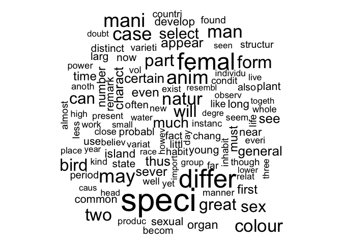

```r
library(wordcloud)
# for Darwin's books
set.seed(1)
wordcloud(dirCorpusDF$word, dirCorpusDF$freq, min.freq = 500)
```

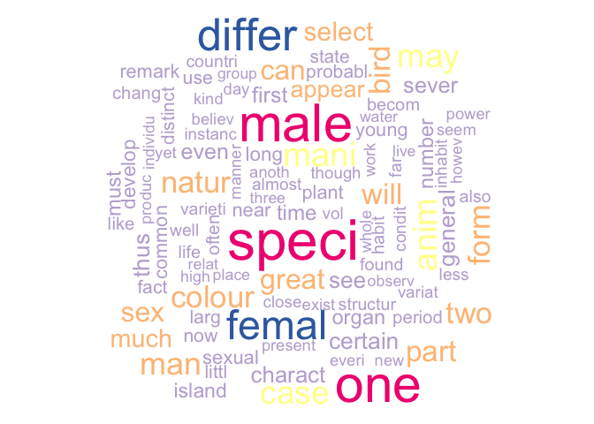

```r
set.seed(1)
wordcloud(dirCorpusDF$word, dirCorpusDF$freq, max.words = 100, rot.per = 0.2,
    colors = brewer.pal(6, "Accent"))
```

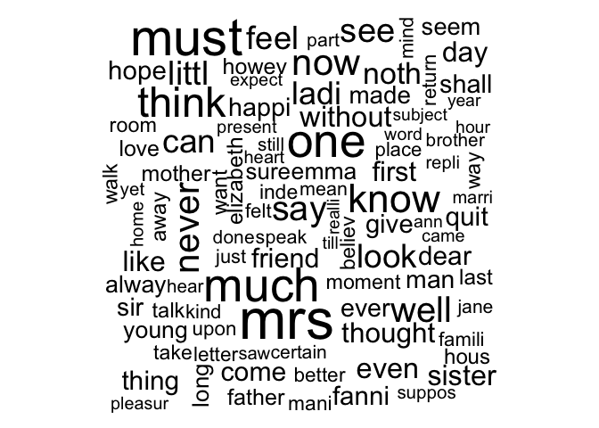

```r
# for Austen's novels
set.seed(1)
wordcloud(fileCorpusDF$word, fileCorpusDF$freq, min.freq = 500)
```

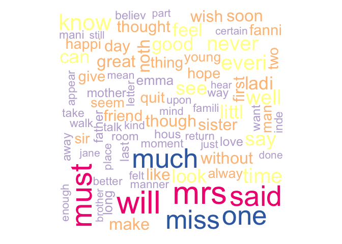

```r
set.seed(1)
wordcloud(fileCorpusDF$word, fileCorpusDF$freq, max.words = 100, rot.per = 0.2,
    colors = brewer.pal(6, "Accent"))
```

[figure not shown]

```r
# for Obama's tweets
set.seed(1)
wordcloud(tweetCorpusDF$word, tweetCorpusDF$freq, min.freq = 500)
```